# Preselect Pipeline

David Martin

2024-12-10

# Overview

The preselection pipeline was designed to identify non-athlete volunteers whose food and nutrient intakes align with those of cyclist groups. Dietary intake data was collected using a Short Form Food Frequency Questionnaire (FFQ), previously validated by Cleghorn CL, Harrison RA, Ransley JK, Wilkinson S, Thomas J, Cade JE. **Can a dietary quality score derived from a short-form FFQ assess dietary quality in UK adult population surveys?** *Public Health Nutrition*. 2016. doi:10.1017/S1368980016001099. Additionally, the weekly physical activity levels of potential participants were recorded. The goal was to recruit 10 participants below the WHO’s physical activity recommendations and 10 above these recommendations (≥600 MET-min/week).

The preselection process involved three main steps:

## 1) Latent Space Projection

First of all, we import data of one volunteer’s questionnaire and the food intakes of the cyclists groups. Their are available in https://github.com/DJrMartin/Gut-Microbiota-and-Physical-Activity/tree/main/data/data_preselect

```r
survey <- read.csv(file="~/Desktop/Preselect_pipeline/data_preselect/Volunteers_example_1.csv", header=T, sep=";")
cyclists <- read.csv(file="~/Desktop/Preselect_pipeline/data_preselect/Food_intakes_cyclists.csv", header=T, sep=";")
```

We confirme that the body mass index is above 18 kg/$m^2$ and under 25 kg/$m^2$.

```r
print(paste('IMC =', round(survey$weight/(survey$height/100)^2, 2)))
```

```
## [1] "IMC = 24.49"
```

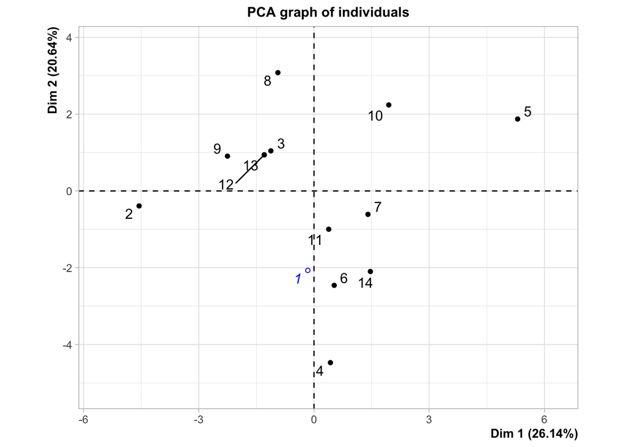

```r
input.pca <- rbind(survey[,-(1:5)], cyclists)
res.pca <- PCA(input.pca, ind.sup = 1, graph=F)
plot(res.pca, choix='ind')
```

Here, the correlation circle of the variables to interpret the two first axis.

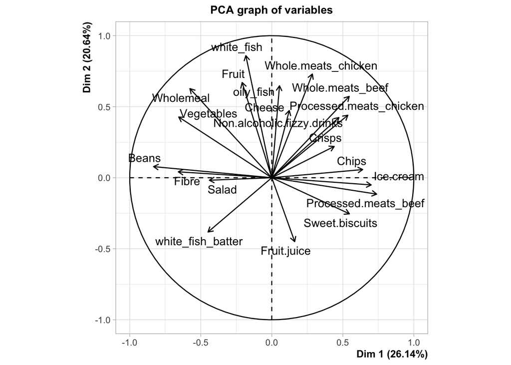

```r
# Plot of the variables
plot(res.pca, choix="var")
```

The coordinates of the supplemental individual, corresponding to the potential volunteer seem in the range of the cyclist group.

## 2) Nutrient Intake Matching

The second verification before including volunteer is to estimate the macro-nutriments (Vegetables, Fat and CHO) and the Dietary Quality Score of the cyclist and the potential volunteer. The corresponding tables to convert food in gramme of macro-nutrients are provided by Cleghorn CL, and al. (2016) in their online supplementary materials. We save their conversion tables in a list called nutrients_conversion. Here, an example with the first cyclist. The output give the equivalent in grammes of Fruits, Fat, Vegetables, CHO and Oil Fish.

```r
nutrient.conversion(cyclists[1,1:13],  # For the vegetables
                    cyclists[1,14:20], # For the meats
                    conversion = nutrients_conversion) # the conversion table
```

```
##   Fruits      Fat Vegetables      CHO Oil.Fish DQS
## 1    120 84.90039        600 61.06378      4.5  12
```

Then, we calculate for the entire cyclists and the potential volunteer…

```r
cyclist.nutrients=NULL
for(i in 1:nrow(cyclists)){
  cyclist.nutrients <- rbind(cyclist.nutrients, nutrient.conversion(cyclists[i,1:13],  # For the vegetables
                    cyclists[i,14:20], # For the meats
                    conversion = nutrients_conversion)) # the conversion table
}
Potential_volunteers <- nutrient.conversion(survey[,6:18],  # For the vegetables
                    survey[,19:25], # For the meats
                    conversion = nutrients_conversion)
```

…and we provide a table visualisation cheking if the potential volunteer respects the inclusion criteria that we choose.

```r
mean_tot=apply(cyclist.nutrients, 2, mean)
sd_tot=apply(cyclist.nutrients, 2, sd)

### Moyenne + 2 x sd #######
max.c=mean_tot+2*sd_tot
min.c=mean_tot-2*sd_tot

inclusion=NULL
for(each in c(1:length(Potential_volunteers))){
  if (Potential_volunteers[each]>min.c[each] & Potential_volunteers[each]<max.c[each]){
    inclusion=c(inclusion, "Yes")
  }else{
    inclusion=c(inclusion, "No")
  }
}
df <- data.frame('individu'=as.numeric(Potential_volunteers),
           'cyclistes_moy'=as.numeric(mean_tot),
           "cyclistes_sd"=2*as.numeric(sd_tot), "Inclusion"=inclusion)
colnames(df)=c('individu','cyclistes_moy', "cyclistes_sd", "Inclusion")
rownames(df)=colnames(Potential_volunteers)
kableExtra::kable(df)
```

|  | individu | cyclistes_moy | cyclistes_sd | Inclusion |
| --- | --- | --- | --- | --- |
| Fruits | 56.80000 | 150.00385 | 207.339795 | Yes |
| Fat | 49.10861 | 65.58080 | 47.925256 | Yes |
| Vegetables | 148.80000 | 189.23077 | 341.769273 | Yes |
| CHO | 67.13062 | 65.48581 | 70.960348 | Yes |
| Oil.Fish | 4.50000 | 11.56154 | 20.468437 | Yes |
| DQS | 11.00000 | 11.69231 | 2.218801 | Yes |

## 3) Activity Profiling

For this last section, we explore the level of physical activity of the potential volunteers. In the questionnaire, we include 3 questions to evalute the time spent in minutes per week where the potential volunteer do a low, moderate or intensive physical exercice. We aimed to recruit 10 participants under the WHO recommendations for physical activity levels, and 10 just above these recommendations (i.e. 600 METS/min/week).

1 minute of a low and moderate physical exercice correspond to 4 METS (basal metabolism) while 1 minute of an intensive physical exercice correspond to 8 METS. It has been proposed in the Global Physical Activity Questionnaire, previously developed by Bull FC, Maslin TS, Armstrong T. **Global physical activity questionnaire (GPAQ): nine country reliability and validity study.** *J Phys Act Health.* 2009. doi: 10.1123/jpah.6.6.790.

```r
print(paste("Potential volunteer exibit a METS-min/week = ",(survey$low_PA+survey$moderate_PA)*4+survey$intense_PA*8))
```

```
## [1] "Potential volunteer exibit a METS-min/week =  600"
```